# bita_midtest

교육부 운영진

2019 10 2

## 1

### 1. 아래의 실행 결과가 나오도록 다음의 빈칸을 완성하세요. (20점)

> 아래의 코드는 시험에 도움을 드리기 위한 기본 틀이며, 다른 방식으로 코드를 작성 하셔도 무방합니다. 단, **for과 if는 반드시** 사용하셔야 하며, 각각의 행에 숫자를 직접 타이핑 하는 것은 정답으로 인정되지 않습니다.

```r
stairs <- data.frame()
for (i in 1:9){
  ____________________________
  if(i <= 5){
   __________________ } else {
    _______________________ }
  }
}
____________________________
stairs
```

#### **< 첫째 열에 있는 1~9는 행번호에 해당함 >**

- data.frame을 만들 때 자동적으로 생성되는 번호입니다.

```
1 1
2 1 2
3 1 2 3
4 1 2 3 4
5 1 2 3 4 5
6 1 2 3 4
7 1 2 3
8 1 2
9 1
```

## 2

### 2-1. 결측치가 “?”로 되어있는 middle_data.txt 를 결측치가 NA로 표기되어 있는 data라는 객체로 불러오고 구조를 확인하세요.(4점)

#### < middle_data.txt 데이터 샘플 >

```
  Oxygen.Saturation Ferritin Class
1                 ?        ?     1
2                 ?        ?     1
3                 6       16     1
4                 ?        ?     0
5                15       22     1
6                22      111     0
```

#### < data 데이터 샘플 >

```r
head(data[,48:50])
```

```
  Oxygen.Saturation Ferritin Class
1                NA       NA     1
2                NA       NA     1
3                 6       16     1
4                NA       NA     0
5                15       22     1
6                22      111     0
```

### 2-2. 결측치의 비율을 뽑아내는 사용자 정의 함수 pMiss를 정의하고 이를 이용해 결측치가 5%미만인 변수들로만 이루어진 새로운 데이터 셋 **data2**를 정의하세요.(4점)

#### < pNA를 사용하여 계산한 결측치 비율 샘플 >

```
                     Gender                    Symptoms
                    0.00000                    10.90909
                    Alcohol Hepatitis.B.Surface.Antigen
                    0.00000                    10.30303
      Hepatitis.B.e.Antigen   Hepatitis.B.Core.Antibody
                   23.63636                    14.54545
```

### 2-3. data2 에 Albumin변수의 결측치를 Albumin의 평균값으로 대체하세요.(4점)

```r
sum(is.na(data2$Albumin))
```

```
[1] 0
```

### 2-4. data2에 결측치를 대체한 Albumin변수를

### **(1.5,2.5]는 0, (2.5,3.5]는 1, (3.5,4.5]는 2, 4.5 초과는 3으로**

### 재범주화한 새로운 변수 **Albumin.cat**을 추가하세요.(4점)

```r
table(data2$Albumin.cat)
```

```
 0  1  2  3
18 79 61  7
```

### 2-5. 2-4와 같이 재범주화 했을 때 장점과 단점을 설명하세요.(4점)

## 3

### 보스턴 주택 데이터(BostionHousing.csv)는 보스턴의 인구조사 지역에서 측정된 여러가지 정보를 담고 있는 데이터로 총 14개의 변수로 구성되어 있습니다.

#### **<변수설명>**

> > NOX : 일산화 질소 농도  
> > DIS : 보스턴 5대 상업지구와의 거리(mile)  
> > PTRATIO : 학생 대 교사비율  
> > AGE : 1940년대 이전에 건축된 주택에 사는 비율  
> > CAT..MEDV : 주택가격의 중앙값이 3만달러 이상 여부(1:이상 / 0:이하)

### 3. 위에서 언급한 5개의 변수만 있는 새로운 데이터 **plot_hs**를 만드세요. 그리고 아래와 같은 박스플랏을 똑같이 만들고 각 박스플랏이 의미하는 바를 해석하세요. (10점)

### 종속변수 **CAT.MEDV**에 대해서 가장 의미있는 독립변수는 무엇이라고 할 수 있으며 그 이유는 무엇인가요? (10점)

> **hint: las=1**

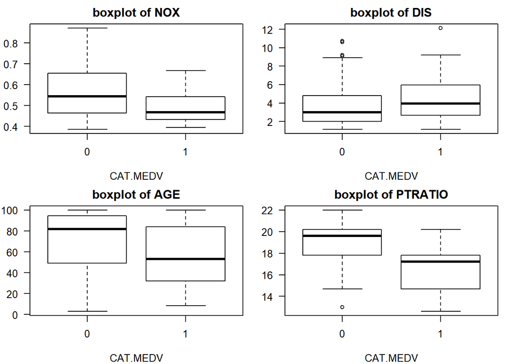

## 4

### **LaptopSalesJanuary2008.csv**는 런던의 한 컴퓨터 체인점의 2008년 1월 매출 데이터입니다.

#### **<변수설명>**

> > Store.Postcode: 매장명  
> > Retail.Price : 소매가격

### 4. 매장별 평균 소매가격을 보여주는 매출 데이터를 아래와 같이 그리세요. 이때 평균 소매가격이 가장 높은 매장과, 낮은 매장을 보라색으로 색칠하세요.(20점)

> **hint : 색상명 = purple**  
> **ifelse() 이용**

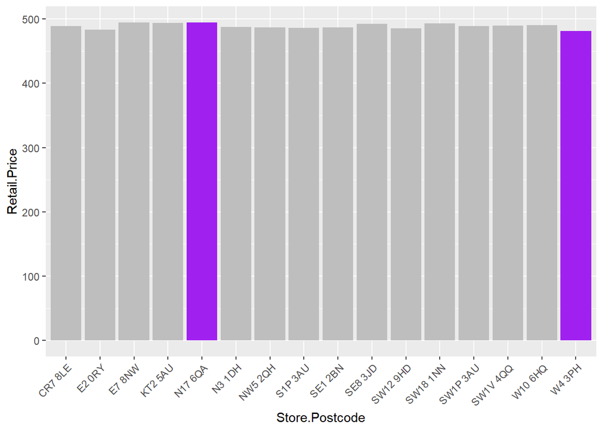

## 5

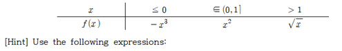

### 5. 위와 같이 정의된 함수를 다음의 그래프와 같게 그리세요.(20점)

> **hint:**  
> **plot(x,y,type=”n”)**  
> **lines(y,x)**

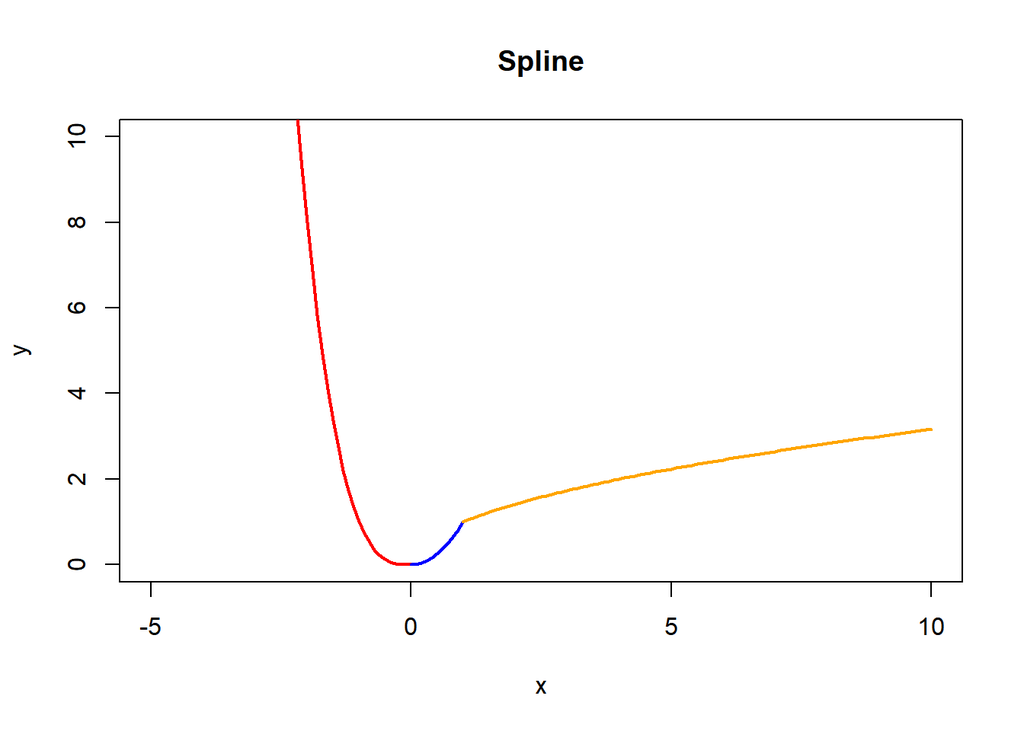